# 3.1b De novo assembly

# Hands-on exercise 3.1b: De novo assembly of bacterial genomes

#### 4/13/2025

# 1 Introduction

**Goal:** Assemble a bacterial genome *de novo* from Illumina short reads

**Input:** Trimmed Illumina paired-end reads in gzipped fastq format (*_trimmedP_1.fastq.gz and *_trimmedP_2.fastq.gz)

**Output:** Contigs and/or scaffolds in fasta format (*.fasta)

**Programs Used:**

- SKESA: a *de novo* assembler for bacterial genomes
- [QUAST](https://github.com/ablab/quast): quality assessment tool for genome assemblies

## 1.1 Learning Outcomes

- Assemble a bacterial genome *de novo* from Illumina short reads
- Assess the quality of a bacterial genome assembly using various metrics

## 1.2 Background

### 1.2.1 Some terminology

- **contig**: a contiguous length of genomic sequence in which the order of bases is known to a high confidence level
- *de novo* assembly: a genome assembled without a reference
- **read**: sequenced base pairs generated from a DNA fragment
- **scaffold**: a construction in which multiple contigs are chained together using additional information about the relative position and orientation of the contigs in the genome; contigs in a scaffold are separated by gaps, which are designated by a variable number of ‘N’ characters

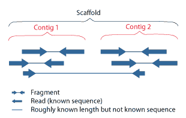

Figure 1: Reads versus contigs versus scaffolds (Wikipedia)

Figure 1: Reads versus contigs versus scaffolds (Wikipedia)

### 1.2.2 From short reads to contigs: how do we assemble bacterial genomes?

The goal of genome assembly is to take thousands, millions, or even billions of short Illumina reads and obtain contigs, or continuous, closed stretches of DNA. Sounds easy, right?

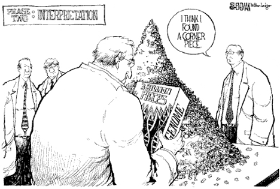

Figure 2: Genome assembly is easy, right? (BioBeans)

Figure 2: Genome assembly is easy, right? (BioBeans)

We can tackle this problem by breaking it into pieces…literally, by using De Bruijn graphs. De Bruijn graphs are a type of directed graph. A directed graph is a structure made up of a set of vertices connected by edges, where the edges have direction.

A De Bruijn graph is a directed graph which represents overlaps between sequences of symbols. Sequences can be reconstructed by moving between nodes in the graph. In the context of reconstructing a genome from Illumina data, the nodes are k-mers, or all possible sub-sequences of length k that are contained in a sequence. For example, if we wanted to find all 3-mers in a sequence of characters, “Salmonella”, we would have the following:

“Sal”, “alm”, “lmo”, “mon”, “one”, “nel”, “ell”, “lla”

Our k-mers will have k-1 overlap (in our case, k-1 = 3-1 = 2). Starting with “Sal”, we need the next 3-mer to begin with “a”, followed by “l”. So our next 3-mer is “alm”:

```
Sal
  alm
```

The third 3-mer needs to begin with “lm”, so it must be “lmo”:

```
Sal
  alm
    lmo
```

And the rest follow:

```
Sal
  alm
    lmo
      mon
        one
          nel
            ell
              lla
```

Another example:

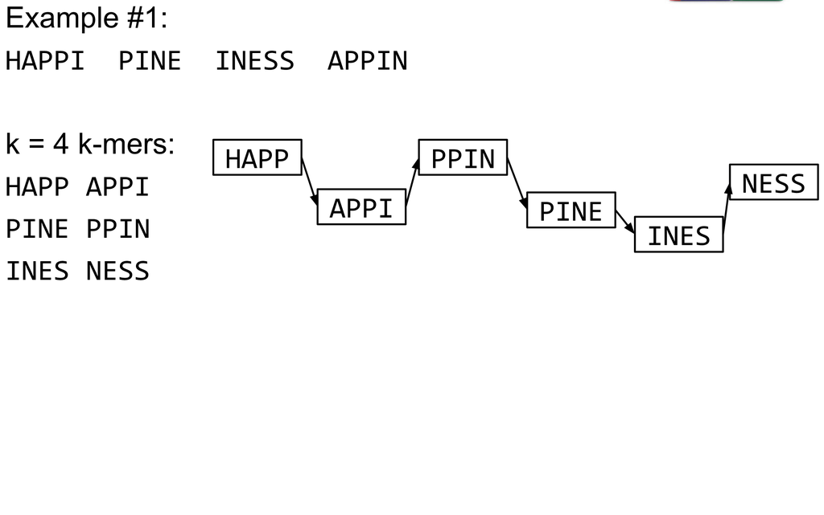

Figure 3: Assembling “happiness” with 4-mers (Galaxy)

Figure 3: Assembling “happiness” with 4-mers (Galaxy)

Another example, this time with a DNA sequence, k = 7, and overlap of 7-1 = 6 nucleotides:

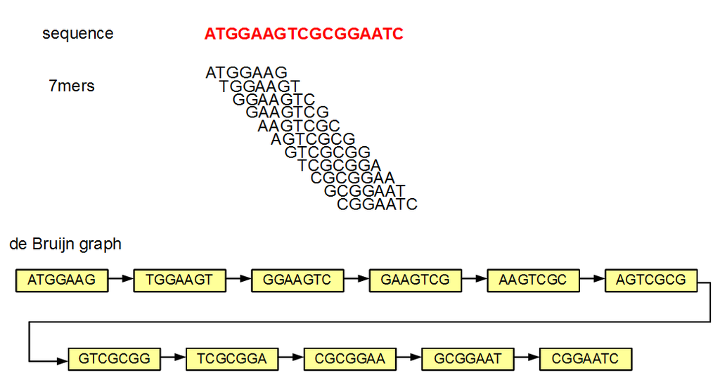

Figure 4: Assembling a nucleotide sequence with 7-mers (homolog.us)

Figure 4: Assembling a nucleotide sequence with 7-mers (homolog.us)

These are obviously some very simple examples. You can probably imagine how this can get complicated pretty quickly:

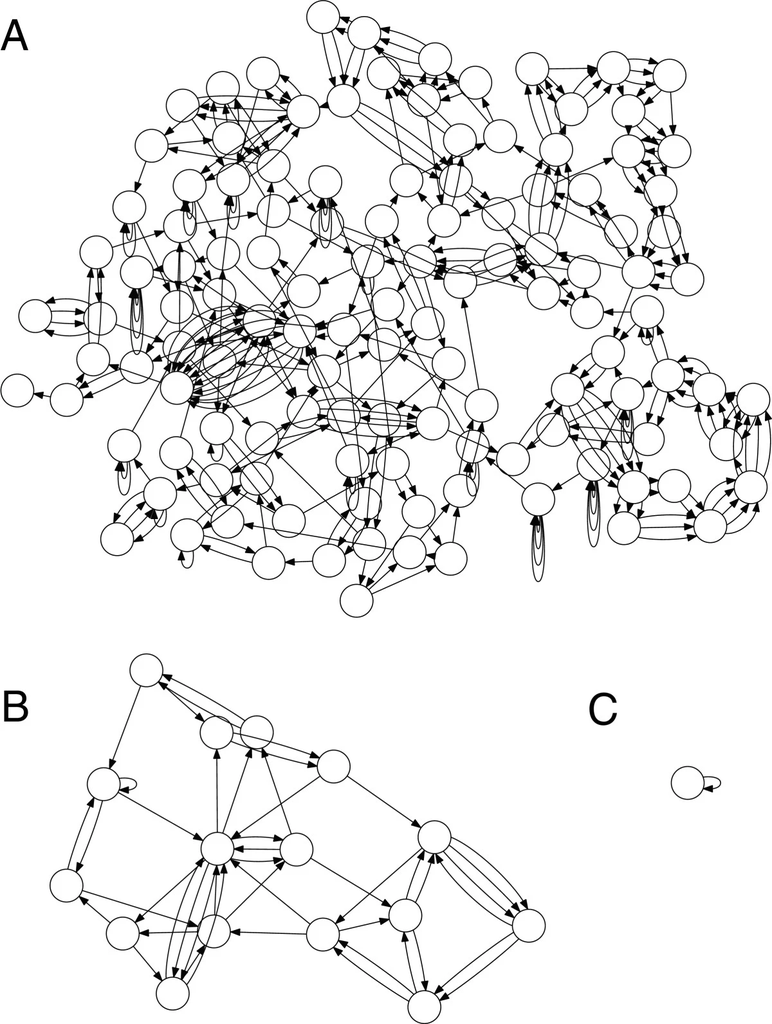

Figure 5: de Bruijn graphs for E. coli K12 where k = 50 (A), k = 1,000 (B), and k = 5,000 (C). (Koren, et al., 2013, Genome Biology)

Figure 5: de Bruijn graphs for E. coli K12 where k = 50 (A), k = 1,000 (B), and k = 5,000 (C). (Koren, et al., 2013, Genome Biology)

Luckily, several assemblers that can be used to asseble bacterial genomes from multicell (i.e., not single-cell) data exist. [SPAdes](https://github.com/ablab/spades) has become one of the most popular bacterial genome assemblers in recent years due to the [improvments it made relative to its predecessors](https://www.ncbi.nlm.nih.gov/pmc/articles/PMC3342519/) (click [here](http://cab.spbu.ru/software/spades/) for some more benchmarking fun). Very recently, however, [SKESA](https://genomebiology.biomedcentral.com/articles/10.1186/s13059-018-1540-z), the assembler used to assemble hundreds of thousands of genomes in NCBI’s Sequence Read Archive (SRA) database, has been made available. There is [some debate](http://cab.spbu.ru/benchmarking-tools-for-de-novo-microbial-assembly/) as to which assembler is best for assembling the genomes of bacterial isolates; however, for this course, we will be using SKESA with our trimmed read pairs (trimmed using fastp), taking advantage of its speed.

### 1.2.3 What makes a good genome assembly?

There are numerous metrics that can be used to assess genome quality, including:

Genome size

Number of contigs

Length of longest contig

N50 (the sequence length of the shortest contig at 50% of the total genome length)

L50 (the smallest number of contigs whose length sum makes up half of genome size)

Distribution of contigs with various lengths (e.g., how many contigs are longer than 1,000 bp? 5,000 bp?)

Number of ambiguous bases (Ns) present in the assembly

Average per-base-pair read coverage

Conveniently, [QUAST](https://github.com/ablab/quast) is able to report many of these metrics for us; as such, we’ll be using it to evaluate the assembled genome of our mystery *Salmonella* isolate.

# 2 Activity 3.2

## 2.1 Assemble a bacterial genome using SKESA

1. Let’s make sure that we are starting from our home directory. To do so, `cd` (change directories) to your home directory:

```bash
cd ~
```

If we type `pwd` to print our current working directory, we should see we are in our home directory:

```bash
pwd
```

If we type `ls`, we should see that our `activity1` directory is still there:

```bash
ls
```

If, for some reason, you accidentally deleted your `activity1` directory, have no fear! Just type `mkdir activity1` to create a new one.

2. To assemble our genome, we are going to want to use our trimmed read pairs that we trimmed using fastp (the trimmedP.fastq.gz files from Activity 3.1). These should be in our `activity1` directory, so let’s move to our `activity1` directory:

```bash
cd activity1
```

If we type `ls`, we should see that the file containing our trimmed forward read pairs for our Mystery Salmonella A isolate, `mystery_salmonella_A_trimmedP_1.fastq.gz`, should be among the files in our current working directory (`activity1`), as well as the file containing its trimmed reverse read pairs, `mystery_salmonella_A_trimmedP_2.fastq.gz`:

```bash
ls
```

If, for some reason, you accidentally deleted your `activity1` directory, or if you deleted your `trimmedP.fastq.gz` files, you can just copy the backup trimmedP files to your `activity1` directory with the following commands! To copy the trimmed forward reads to your computer:

```bash
wget http://beagle.henlab.org/public/course_introtobioinfo/mystery_salmonella_A_trimmedP_1.fastq.gz
```

To copy the trimmed reverse reads to your computer:

```bash
wget http://beagle.henlab.org/public/course_introtobioinfo/mystery_salmonella_A_trimmedP_2.fastq.gz
```

These results were obtained by running fastp using the exact same commands that you ran previously, with the exact same input files!

3. Now that we have our forward and reverse trimmed read pairs in gzipped fastq format (`.fastq.gz`), let’s use SKESA to assemble our genome *de novo* (i.e., without a reference genome).

Let’s start by loading the SKESA module; note that there are some other modules we need to load before loading `SKESA` (we can see this by running `module spider SKESA`):

```bash
module purge > /dev/null 2>&1
ml GCC/13.2.0  OpenMPI/4.1.6
ml SKESA/2.4.0_saute.1.3.0_2
```

To make sure SKESA is loaded, let’s check which version we’ve installed:

```bash
skesa --version
```

We can also print the help screen for SKESA:

```bash
skesa --help
```

4. The general format for running SKESA using paired-end Illumina reads from a bacterial isolate is as follows (note: don’t execute this command; it is just an example):

```bash
skesa --reads </path/to/isolate_trimmedP_1.fastq.gz>,</path/to/isolate_trimmedP_2.fastq.gz> --cores <number of cores> --memory <memory available in Gb> --contigs_out <name of output fasta file>
```

Let’s go through this command, piece-by-piece:

- **We call the command `skesa` (`skesa`)**
- **We supply the paths to the fastq.gz files containing trimmed forward and reverse read pairs, separated by a comma: `--reads </path/to/isolate_trimmedP_1.fastq.gz>,</path/to/isolate_trimmedP_2.fastq.gz>`**

In our case, this will just be `--reads mystery_salmonella_A_trimmedP_1.fastq.gz,mystery_salmonella_A_trimmedP_2.fastq.gz`

- **Number of cores to use: `--cores <number of cores>`**

- **Memory available in gigabytes: `--memory <memory available in Gb>`**

- **Name of the desired output fasta file: `--contigs_out <name of output fasta file>`**

You can hypothetically name your output file anything, but let’s name ours after the isolate we are querying (we’ll use the extension `.fna`, because SKESA produces a fasta file, which contains the assembled contigs): `--contigs_out mystery_salmonella_A.fna`

Now, let’s put it all together by running the following command:

```bash
skesa --reads mystery_salmonella_A_trimmedP_1.fastq.gz,mystery_salmonella_A_trimmedP_2.fastq.gz --cores 4 --memory 16 --contigs_out mystery_salmonella_A.fna
```

5. Wait! Assembling our genome can take a bit of time (10-15 minutes or so).

## 2.2 Assess the quality of an assembled genome using QUAST

1. Let’s start by making sure that we are starting from our `activity1` directory, which is in our home (`~`) directory. To move to our `activity1` directory, run the following command:

```bash
cd ~/activity1
```

If we type `pwd`, we should see that we are now in `activity1`:

```bash
pwd
```

If we type `ls`, we should see that the output file we created while running SKESA, `mystery_salmonella_A.fna` is present among the files in `activity1`:

```bash
ls
```

2. Now that we have an assembled genome (`mystery_salmonella_A.fna`), let’s use [QUAST](https://github.com/ablab/quast) to assess the quality of our genome. QUAST provides various metrics which we can use to evaluate the quality of our assembled genome.

Let’s start by loading the QUAST module; note that there are some other modules we need to load before loading `QUAST` (we can see this by running `module spider QUAST`):

```bash
module purge > /dev/null 2>&1
ml GCC/13.2.0
ml QUAST/5.2.0
```

To check if QUAST is loaded, run the following command to check its version:

```bash
quast --version
```

3. The general format for running QUAST to evaluate an assembled genome in fasta format is as follows (note: don’t execute this command; it is just an example):

```bash
quast -o </path/to/desired/output_directory> --min-contig 1 </path/to/input/contigs.fasta>
```

While QUAST has many options other than this (use `quast -h` to see them), we will just supply our input assembly (`mystery_salmonella_A.fna`), an output directory (we could name this anything, but let’s call it `mystery_salmonella_A_quast`), the number of threads (this depends on our computer, but here we will just use `--threads 1`), and we will change the `--min-contig` option to `--min-contig 1` (by default, QUAST sets this parameter to `--min-contig 500`, but we will lower it to 1 to consider all of our contigs in our assembly, not just those over 500 bp in length)

To that end, run QUAST using the following command:

```bash
quast -o mystery_salmonella_A_quast --threads 1 --min-contig 1 mystery_salmonella_A.fna
```

4. When QUAST finishes, we can take a look at one of the text files with a summary of our results. If we type `ls` and supply the path to our directory with our QUAST results, `mystery_salmonella_A_quast`, we’ll see that QUAST has produced numerous reports:

```bash
ls mystery_salmonella_A_quast
```

If you want to look at the graphical reports that QUAST produced, you can open them in your browser. However, we can quickly view one of the short text-based reports, `report.txt`, using `cat`, which will print the text to our terminal in its entirety:

```bash
cat mystery_salmonella_A_quast/report.txt
```

We can see a lot of valuable statistics for our assembled genome, including its N50, L50, total length, longest contig, distribution of contig lengths, and GC content.

# 3 References

Bankevich, Anton, et al. 2012. [SPAdes: A New Genome Assembly Algorithm and Its Applications to Single-Cell Sequencing.](https://www.ncbi.nlm.nih.gov/pmc/articles/PMC3342519/) *Journal of Computational Biology* 19(5): 455–477.

Gurevich, Alexey, et al. 2013. [QUAST: quality assessment tool for genome assemblies.](https://www.ncbi.nlm.nih.gov/pmc/articles/PMC3624806/) *Bioinformatics* 29(8): 1072–1075.

JGI. “What is a Scaffold?” Accessed April 15, 2019. URL: https://genome.jgi.doe.gov/help/scaffolds.jsf.

Koren, S., et al. 2013. [Reducing assembly complexity of microbial genomes with single-molecule sequencing.](https://www.ncbi.nlm.nih.gov/pmc/articles/PMC4053942/) *Genome Biology* 14(9):R101.

PacBio Blog. September 21, 2016. “Genomes vs. GenNNNes: The Difference between Contigs and Scaffolds in Genome Assemblies”. Accessed April 15, 2019. URL: https://www.pacb.com/blog/genomes-vs-gennnnes-difference-contigs-scaffolds-genome-assemblies/

Souvorov, Agarwala, and Lipman. 2018. [SKESA: strategic k-mer extension for scrupulous assemblies.](https://genomebiology.biomedcentral.com/articles/10.1186/s13059-018-1540-z) *Genome Biology* 19: 153.

## Extra exercise material

Theoretical questions on assembly metrics, k-mers, de Bruijn graphs, repeats, and coverage. Pen-and-paper unless a code chunk is shown.

- **QE1.1** Given contigs of length 1000, 700, 500, 400, 200, 100, 50 (total = 2950 bp), compute **N50** and **L50** step by step. Why is N50 sensitive to one very long contig?

**Hint**

Sort contigs from longest to shortest, then keep adding their lengths until you have passed half the total. The length of the contig that pushed you over half is N50; the count of contigs you needed is L50.

**Solution**

```r
lens <- c(1000, 700, 500, 400, 200, 100, 50)
lens <- sort(lens, decreasing = TRUE)
half <- sum(lens) / 2
csum <- cumsum(lens)
i <- which(csum >= half)[1]
list(N50 = lens[i], L50 = i, total = sum(lens), half = half)
```

```
$N50
[1] 700

$L50
[1] 2

$total
[1] 2950

$half
[1] 1475
```

Walking through: cumulative sums are 1000, 1700, 2200, … — half of 2950 is 1475, which is first exceeded at index 2 (cumulative 1700). So **N50 = 700, L50 = 2**.

N50 is sensitive to a single long contig because it’s a *weighted median* — half the assembly’s bases live in contigs ≥ N50. Stretching one contig pulls a lot of bases over the half-way mark, dragging N50 up. Reporting alongside L50 and total assembly length is essential to avoid being misled.

- **QE1.2** How many distinct k-mers can you extract from a single 150 bp read at k = 31? At k = 99?

**Hint**

A k-mer is a window of size k sliding along the read, one base at a time. Count the positions the window can start at.

**Solution**

The window can start at positions 1, 2, …, L − k + 1 (any later start runs off the end). So a 150 bp read gives:

- **k = 31**: 150 − 31 + 1 = **120 k-mers**.
- **k = 99**: 150 − 99 + 1 = **52 k-mers**.

The larger you pick k, the fewer k-mers you get per read — and so the more raw reads you need to give the assembler the same amount of evidence.

- **QE1.3** What goes wrong if k is **too small** (say k = 7) for a 5 Mb bacterial genome? What goes wrong if k is **too large** (say k = 99 with 150 bp reads)? Sketch the trade-off.

**Hint**

For each extreme, ask: how many distinct k-mers are *possible*, and how many *actually appear* in the genome? When k is small, are k-mers likely to be unique? When k is large, how many k-mers do you get per read?

**Solution**

Sweet spot for short Illumina + bacterial genome is typically k = 31–55. The trade-off: small k → graph is dense and tangled (repeats merge); large k → graph is sparse and broken (gaps and errors dominate).

- **QE1.4** Write out all 3-mers (k = 3) in the sequence `ATGGAA`. There should be 4 of them. Show how each pair of consecutive 3-mers overlaps by 2 letters (this is what the de Bruijn graph captures).

**Hint**

Slide a window of size 3 along the sequence, one base at a time.

**Solution**

The 3-mers (in order along the sequence) are: `ATG, TGG, GGA, GAA`.

Each consecutive pair shares 2 letters — that overlap is what the de Bruijn graph uses to link them:

```
ATG
 TGG     (overlap = TG)
  GGA    (overlap = GG)
   GAA   (overlap = GA)
```

Concatenating the first letter of each k-mer plus the last two letters of the final one recovers the original `ATGGAA`.

- **QE1.5** A genome contains the motif `ACTGCT` (length 6) at three different positions. Sketch what the de Bruijn graph looks like around the repeat for **k < 6** versus **k > 6**. Explain in one sentence why repeats longer than k cause assembly fragmentation.

**Hint**

At what k does the entire repeat fit inside a single k-mer? Until that happens, the repeat is “stitched together” from shorter pieces shared by all three copies.

**Solution**

- **k < 6 (e.g. k = 4).** Every 4-mer inside `ACTGCT` (`ACTG`, `CTGC`, `TGCT`) occurs three times in the genome. The graph has a single shared “ACTGCT” path that all three copies funnel through, with three incoming edges (one per upstream context) and three outgoing edges (one per downstream context). The assembler can’t tell which incoming edge pairs with which outgoing — it has to stop and start a new contig at each junction.
- **k > 6 (e.g. k = 7).** A 7-mer like `XACTGCT` includes one upstream base, so each of the three repeat copies has a *distinct* 7-mer. The repeat is no longer shared: the path is unique per copy, and the assembler can extend straight through.

**One-liner:** repeats longer than k merge into a single shared graph node, creating ambiguous junctions that the assembler can only resolve by ending contigs.

- **QE1.6** List **three** properties of bacterial genomes that make them easier to assemble than eukaryotic ones, and **one** property that still makes bacterial assembly hard.

**Hint**

Think about: size, repeat content, ploidy, and the kinds of repeats that do exist in bacteria (e.g. rRNA operons, mobile elements).

**Solution**

Bacterial assembly is easier because:

1. **Small genome** (typically 1–10 Mb) — modest k-mer space, modest compute.
2. **Haploid** — no allelic heterozygosity to disentangle (a SNP either is or isn’t there).
3. **Low repeat content** — most of the genome is unique single-copy sequence; in eukaryotes, 30–70 % can be repetitive.

Bacterial assembly is **still hard** because rRNA operons (5S–16S–23S) are typically present in 5–7 nearly-identical copies and are several kb long — well beyond Illumina read length. These collapse in the de Bruijn graph and produce the most common gaps in bacterial assemblies.

- **QE1.7** A QUAST run on a *Salmonella* assembly reports: N50 = 12 kb, total length = 5.1 Mb, # contigs = 850, # Ns = 4000, largest contig = 85 kb. Is this a “good” assembly? Defend your answer using at least three metrics.

**Hint**

What do you *expect* for a *Salmonella* genome? Compare each metric to that expectation.

**Solution**

*Salmonella enterica* has a ~5 Mb circular chromosome, ideally producing one or a few large contigs in a perfect assembly.

- **Total length (5.1 Mb)** — matches the expected genome size. ✓ The assembly is neither truncated nor inflated by contamination.
- **# contigs (850)** — far higher than ideal. A clean short-read *Salmonella* assembly is typically 50–200 contigs; 850 suggests low coverage, high error, or stringent filtering kept tiny contigs.
- **N50 (12 kb)** — modest. Good short-read assemblies hit 50–200 kb. Twelve kb means half the assembly is in contigs *shorter* than a typical operon.
- **Largest contig (85 kb)** — reasonable but not great; the rRNA operons (≈5 kb × 7 copies) and IS elements are still breaking things up.
- **# Ns (4000)** — small relative to 5 Mb (~0.08 %); the contigs themselves are clean, the fragmentation is the issue.

**Verdict:** usable for variant calling and gene presence/absence (where contiguity matters less), but you’d want long-read scaffolding (Nanopore/PacBio) before publishing or doing structural variant work.

- **QE1.8** Single reads can’t span a repeat longer than the read length. How does paired-end information help bridge such a repeat in the de Bruijn graph? What insert size would you choose for a genome whose longest repeat is ~700 bp?

**Hint**

A read pair “anchors” two reads at known distance apart. If one end maps to unique sequence and the other end maps just past the repeat…

**Solution**

A repeat longer than the read collapses into a single shared graph node with multiple incoming and outgoing edges (see QE1.5). A read pair with insert size > repeat length provides the missing information: read 1 anchors in the *unique* region upstream of the repeat, read 2 anchors in the *unique* region downstream. Both reads sit on either side of the repeat, even if neither one spans it. The assembler / scaffolder can now match incoming edge X with the correct outgoing edge Y, because the unique anchors on the read pair commit to a specific pairing.

For a 700 bp repeat, you want the *insert size* (not the read length) to comfortably exceed 700 bp — so an insert size around 800–1000 bp gives you anchors on both flanks for most pairs. Add a margin for insert-size variability: a 250 bp mean insert won’t help here; a 600 bp mean insert helps only some of the time; ~1 kb is comfortable.

- **QE1.9** Short reads give per-base accuracy but fragment at repeats; long reads span repeats but have a higher per-base error rate. Sketch a **hybrid** assembly workflow that combines the two. What does each read type contribute?

**Hint**

Use one read type for *contiguity / structure* and the other for *base-level correctness*. In what order would you apply them?

**Solution**

A typical hybrid workflow (e.g. with Unicycler or Trycycler + Polypolish/Pilon):

1. **Assemble long reads** (Nanopore or PacBio HiFi) with `flye` or `canu` → produces few, long contigs that span repeats and rRNA operons. Often closes the genome to a single circular chromosome + plasmids.
2. **Polish with short reads** — map Illumina reads back to the long-read assembly and correct base-level errors with `polypolish` or `pilon`. This typically fixes the systematic homopolymer indels that Nanopore is prone to.
3. **Verify** — re-map short reads, look for residual mismatches, check completeness with `BUSCO` or `CheckM`.

What each side contributes:

- **Long reads → contiguity / structure.** They span repeats > read length and resolve graph branches. Without them, repeats fragment the assembly.
- **Short reads → per-base accuracy.** They fix the small (1–2 bp) errors that long reads leave behind, especially in homopolymer runs.

PacBio HiFi has narrowed the gap (per-base Q30 *and* long), so HiFi-only assemblies are increasingly competitive — but for many labs, hybrid Illumina + Nanopore is still the cost-effective sweet spot.